# データ解析論II第6講

## 目次

## 前回の復習

## 因子分析とは

\(観測変数 = 共通因子 + 独自因子\)

- ある観測された変数が，どのような潜在的な変数の影響を受けているのか分析する手法
  - 心理学分野だと「構成概念」として議論されている．
- 観測変数：実際に観測された変数
  - ex.国語の点数，数学の点数，社会の点数，理科の点数etc.
- 共通因子：複数の要因に共通する特徴
  - 国語と社会には「文系能力」という潜在変数が共通因子として存在する．
  - 数学と理科には「理系能力」という潜在変数が共通因子として存在する．
- 独自因子：各項目における固有の要因
  - 国語独自の問題，数学独自の問題，社会独自の問題，理科独自の問題，
  - 独自因子は「誤差」として扱う

\(観測変数 = 共通因子 + e_i\)

## 2種類の因子分析

- 探索的因子分析：どのような因子存在して影響を与えているのか，よくわからない場合などに用いる．
  - ex.新しい質問紙を開発する時に用いる
- 確証的因子分析：先行研究や仮説にあわせて因子構造を確認する
  - ex.既に先行研究で検証されている質問紙を使う時に用いる．

## 探索的因子分析の手続き

- 因子分析を行う意義の確認
  - Kaiser-Meyer-Olkinの標本妥当性の測度（KMO 測度）：データに少なくとも１つの潜在因子が存在しそうかどうかを検証する．
  - これは行う時と行わない時があるが，最近はやりがち．
- 因子数の決定
  - ガットマン基準：観測変数の相関行列の固有値をもとに因子数を決定する，値が1.0以上のものを採用
  - スクリープロット：固有値を縦軸，因子の番号を横軸として，固有値の変化をプロットしたグラフ．固有値の値がなだらかになる直前までの固有値の数を因子数とする．
  - 平行分析：変数の標本サイズが実際のデータと同一の乱数データを作成して，そこから固有値平均をもとめて比較する．
- 因子負荷の推定
  - 観測変数が書く因子をどの程度反映しているかが示される．
  - 探索的因子分析では，因子不可は各観測変数につき，因子の数だけ推定される．
    - 重回帰分析でフルモデルから考えているようなもの
  - 各因子がどのような構成概念を反映したものであるかは，推定された因子負荷の値を見て判断する．
- 因子数が複数の時は因子軸の回転
  - 因子が単純構造であるほうが解釈がしやすいため，単純構造になるようにする．
    - 単純構造：各観測変数が1つの因子だけから高い因子負荷を受け，他の因子からの因子負荷が0に近い状況
  - 単純構造に成るように因子軸の回転を行う．
    - PROMAX回転がよく使われる．
- 因子の解釈
  - 各因子を強く反映する変数の内容から，その因子の内容を推測すること．
    - 各因子がどのような概念を示しているかについて，因子名をつける．

## 今日扱うデータの概要

- 今回扱うデータ：クラウドソーシングを用いた意思決定に関するデータの一部
  - 現在分析中のデータなので，あまり外部に流出しないように気をつけてください．

[**データ**](https://www.dropbox.com/sh/ld9wqf25rjl3ege/AAD667w9lS2j12yX_32V5xhya?dl=0)

この中から，ratemo_1からratemo_24までのデータを分析する．

- REI日本語版：情報処理スタイル尺度，直観的処理と合理的処理における個人差を明らかにする尺度（内藤et.al, 2004）
  - Epstein et. al（1996）のREI(Rational Experiential Inventory)の日本語版
- 短縮版を採用
- 直観・感情的な反応を示すシステム1と論理・理性的な思考をもたらすシステム2を反映
  - Kahneman, 2012; Evans, 2010
- [**参考資料①**](https://www.jstage.jst.go.jp/article/personality/13/1/13_1_67/_pdf/-char/ja)

| 逆転項目 | 短縮版 | 順番 | 項目 |
| --- | --- | --- | --- |
|  | ＊ | 1 | たいていの人より，ものごとを論理的に解決するのが上手である． |
| ＊ | ＊ | 2 | 直観に頼らなければならない状況は好きではない． |
|  | ＊ | 3 | 自分の予感を信じることにしている． |
|  | ＊ | 4 | 論理的な考えの持ち主だ． |
| ＊ | ＊ | 5 | ものごとを注意深く理論的に解決するのは，得意ではない． |
|  | ＊ | 6 | 簡単な問題より複雑な問題の方が好きだ． |
|  | ＊ | 7 | なぜだか理由を説明できないが，その人が正しいか間違っているかを，感じとることができる． |

| 逆転項目 | 短縮版 | 順番 | 項目 |
| --- | --- | --- | --- |
| ＊ | ＊ | 8 | 分析的に考える方ではない． |
| ＊ | ＊ | 9 | 私にはすごい直観力はない． |
| ＊ | ＊ | 10 | 考えることは，楽しいことだと思わない． |
|  | ＊ | 11 | 直観は問題を解決するのに役立つ方法だろう． |
| ＊ | ＊ | 12 | 感情に基づいて重要な決定をするのは，愚かなことだと思う． |
|  | ＊ | 13 | 行動を決める時，直観に頼ることが多い． |
|  | ＊ | 14 | 私にとって，新しい考え方を学ぶことは，とても魅力的である． |

| 逆転項目 | 短縮版 | 順番 | 項目 |
| --- | --- | --- | --- |
| ＊ | ＊ | 15 | 複雑な問題を解決するのは，得意ではない． |
|  | ＊ | 16 | 知的な挑戦が好きだ． |
| ＊ | ＊ | 17 | 直観に頼って重要な決定をするのは，いい考えだと思わない． |
| ＊ | ＊ | 18 | もし私が直観に頼るならば，間違いをおかすことが多くなるだろう． |
|  | ＊ | 19 | 直観的な印象に頼るのが好きだ． |
|  | ＊ | 20 | 一生懸命考えなければならないような問題を解決するのが好きだ． |

| 逆転項目 | 短縮版 | 順番 | 項目 |
| --- | --- | --- | --- |
|  | ＊ | 21 | 答えを見つけるために直観に従って，うまくいかなかったことはほとんどない． |
|  | ＊ | 22 | 人生や生活上のいろんな問題を考えるとき，直観的にやるとうまくいく． |
| ＊ | ＊ | 23 | 注意深く論理的な分析が必要とされる問題を解決するのは，得意ではない． |
| ＊ | ＊ | 24 | いろいろ考えるのは好きではない． |

## 逆転項目とは

- 逆転項目：他の質問項目とは違い，測定の向きが逆であるデータ．
  - 因子分析を行う際には，逆転項目は反転させる必要がある．
- 今回の調査では：
  - 「1 ：全くあてはまらない」「2 ：あまりあてはまらない」「3 ：どちらともいえない」「4 ：少しあてはまる」「5 ：非常にあてはまる」
  - 逆転項目については1→5，2→4，3→3，4→2，5→1に置き換える必要がある．
  - 該当項目については6からそれぞれの値を引いてあげれば良い．

## 逆転項目に対応しよう

```r
library(readr)
factanal <- read_csv("../data/factanal.csv")

library(dplyr)
factanal <- mutate(factanal, gyaku_ratemo_2=6-ratemo_2)
factanal <- mutate(factanal, gyaku_ratemo_5=6-ratemo_5)
factanal <- mutate(factanal, gyaku_ratemo_8=6-ratemo_8)
factanal <- mutate(factanal, gyaku_ratemo_9=6-ratemo_9)
factanal <- mutate(factanal, gyaku_ratemo_10=6-ratemo_10)
factanal <- mutate(factanal, gyaku_ratemo_12=6-ratemo_12)
factanal <- mutate(factanal, gyaku_ratemo_15=6-ratemo_15)
factanal <- mutate(factanal, gyaku_ratemo_17=6-ratemo_17)
factanal <- mutate(factanal, gyaku_ratemo_18=6-ratemo_18)
factanal <- mutate(factanal, gyaku_ratemo_23=6-ratemo_23)
factanal <- mutate(factanal, gyaku_ratemo_24=6-ratemo_24)
```

## 分析の準備

```r
#install.packages( "psych" )
#install.packages( "GPArotation" )

library( psych )
library( GPArotation )
```

- この2つのパッケージを用います．必要に応じてインストールをしてください．

## 新たなデータセットの作成

- 必要なデータだけを取り出します．

```r
library(dplyr)
REI <- factanal %>%
  select(c(ratemo_1,gyaku_ratemo_2,ratemo_3,ratemo_4,
           gyaku_ratemo_5,ratemo_6,ratemo_7,gyaku_ratemo_8,
           gyaku_ratemo_9,gyaku_ratemo_10,ratemo_11,
           gyaku_ratemo_12,ratemo_13,ratemo_14,
           gyaku_ratemo_15,ratemo_16,gyaku_ratemo_17,
           gyaku_ratemo_18,ratemo_19,ratemo_20,
           ratemo_21,ratemo_22,gyaku_ratemo_23,
           gyaku_ratemo_24))
```

## 分析の前のデータチェック

- Kaiser-Meyer-Olkinの標本妥当性の測度（KMO 測度）でデータに少なくとも１つの潜在因子が存在しそうかを調べます．
  - Overall MSAが0.6以上であることが望ましい．

```r
    KMO(REI)
```

```
## Kaiser-Meyer-Olkin factor adequacy
## Call: KMO(r = REI)
## Overall MSA =  0.9
## MSA for each item =
##        ratemo_1  gyaku_ratemo_2        ratemo_3        ratemo_4  gyaku_ratemo_5
##            0.88            0.90            0.90            0.87            0.90
##        ratemo_6        ratemo_7  gyaku_ratemo_8  gyaku_ratemo_9 gyaku_ratemo_10
##            0.92            0.86            0.92            0.90            0.91
##       ratemo_11 gyaku_ratemo_12       ratemo_13       ratemo_14 gyaku_ratemo_15
##            0.92            0.85            0.91            0.90            0.92
##       ratemo_16 gyaku_ratemo_17 gyaku_ratemo_18       ratemo_19       ratemo_20
##            0.92            0.87            0.89            0.91            0.91
##       ratemo_21       ratemo_22 gyaku_ratemo_23 gyaku_ratemo_24
##            0.91            0.91            0.93            0.92
```

## スクリープロットの作成：

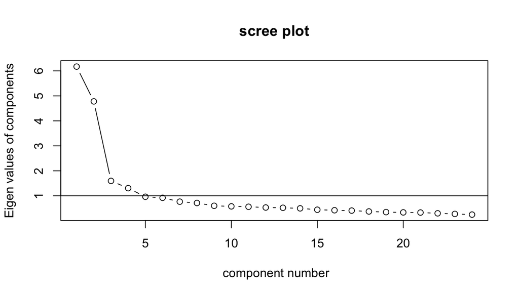

```r
correlation = cor(REI) # 相関行列の計算
VSS.scree(REI) # スクリープロットの表示
```

- Screeplot：ある成分や因子に対して，それに対応する固有値を降順でプロットしたグラフのこと． 因子や成分の寄与の大きさの指標となる．
  - 固有値がガクッと曲がっているところが因子数の基準．
  - 固有値：分散の大きさの基準．因子が増えると分散を小さくできるけど，たくさんあるとめんどいから，程々のところで考えよう．

## 平行分析：

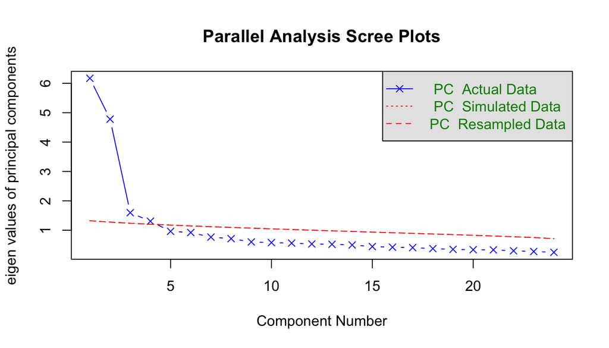

```
## Parallel analysis suggests that the number of factors =  NA  and the number of components =  4
```

```r
fa.parallel(REI, fa = "pc" , n.iter = 100)
```

- 平行分析：変数の数と標本サイズが実際のデータと同じ乱数データをn個作成して，n個の乱数データそれぞれで固有値を算出し，n個の固有値の平均を算出します．

## MAP基準とBIC基準：

- 因子数決定の統計的な基準として，MAP基準およびBIC基準があります．

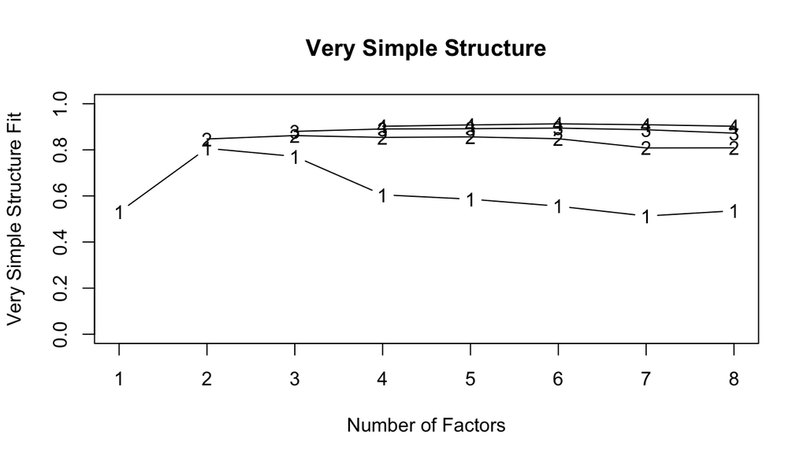

```
##
## Very Simple Structure
## Call: vss(x = x, n = n, rotate = rotate, diagonal = diagonal, fm = fm,
##     n.obs = n.obs, plot = plot, title = title, use = use, cor = cor)
## VSS complexity 1 achieves a maximimum of 0.81  with  2  factors
## VSS complexity 2 achieves a maximimum of 0.86  with  3  factors
##
## The Velicer MAP achieves a minimum of 0.01  with  4  factors
## BIC achieves a minimum of  -670.5  with  6  factors
## Sample Size adjusted BIC achieves a minimum of  -206.51  with  7  factors
##
## Statistics by number of factors
##   vss1 vss2   map dof chisq     prob sqresid  fit RMSEA  BIC SABIC complex
## 1 0.53 0.00 0.048 252  4640  0.0e+00    33.4 0.53 0.148 2958  3758     1.0
## 2 0.81 0.85 0.018 229  1925 2.2e-265    10.9 0.85 0.097  396  1123     1.1
## 3 0.77 0.86 0.016 207  1246 7.5e-148     8.5 0.88 0.080 -136   522     1.3
## 4 0.60 0.85 0.014 186   704  3.1e-61     7.0 0.90 0.059 -538    52     1.6
## 5 0.59 0.86 0.016 166   515  2.5e-37     6.2 0.91 0.051 -594   -67     1.7
## 6 0.56 0.85 0.019 147   311  8.2e-14     5.6 0.92 0.037 -671  -204     1.9
## 7 0.51 0.81 0.022 129   245  3.1e-09     5.2 0.93 0.034 -616  -207     2.0
## 8 0.54 0.81 0.027 112   198  9.6e-07     4.8 0.93 0.031 -550  -194     2.2
##   eChisq  SRMR eCRMS  eBIC
## 1  14502 0.182 0.190 12819
## 2   1755 0.063 0.069   226
## 3    918 0.046 0.053  -464
## 4    415 0.031 0.037  -827
## 5    274 0.025 0.032  -834
## 6    140 0.018 0.025  -841
## 7     99 0.015 0.022  -762
## 8     70 0.013 0.020  -678
```

```r
VSS(REI) # MAP基準およびBIC基準による因子数の検証
```

## 因子負荷の推定：

```r
fa_REI <- fa(REI, nfactors = 2, fm = "ml", rotate = "none")
fa_REI
```

```
## Factor Analysis using method =  ml
## Call: fa(r = REI, nfactors = 2, rotate = "none", fm = "ml")
## Standardized loadings (pattern matrix) based upon correlation matrix
##                   ML1   ML2   h2   u2 com
## ratemo_1         0.66 -0.11 0.45 0.55 1.1
## gyaku_ratemo_2   0.10  0.54 0.30 0.70 1.1
## ratemo_3         0.21  0.54 0.33 0.67 1.3
## ratemo_4         0.65 -0.21 0.47 0.53 1.2
## gyaku_ratemo_5   0.65 -0.10 0.43 0.57 1.1
## ratemo_6         0.66 -0.10 0.44 0.56 1.0
## ratemo_7         0.25  0.36 0.19 0.81 1.8
## gyaku_ratemo_8   0.60 -0.22 0.41 0.59 1.3
## gyaku_ratemo_9   0.31  0.52 0.36 0.64 1.6
## gyaku_ratemo_10  0.62 -0.07 0.39 0.61 1.0
## ratemo_11        0.13  0.61 0.39 0.61 1.1
## gyaku_ratemo_12  0.02  0.48 0.23 0.77 1.0
## ratemo_13       -0.12  0.66 0.44 0.56 1.1
## ratemo_14        0.47  0.03 0.22 0.78 1.0
## gyaku_ratemo_15  0.74 -0.01 0.54 0.46 1.0
## ratemo_16        0.73 -0.08 0.54 0.46 1.0
## gyaku_ratemo_17  0.11  0.67 0.46 0.54 1.1
## gyaku_ratemo_18  0.23  0.60 0.41 0.59 1.3
## ratemo_19        0.02  0.75 0.56 0.44 1.0
## ratemo_20        0.70 -0.03 0.49 0.51 1.0
## ratemo_21        0.10  0.43 0.20 0.80 1.1
## ratemo_22        0.18  0.69 0.51 0.49 1.1
## gyaku_ratemo_23  0.74 -0.09 0.56 0.44 1.0
## gyaku_ratemo_24  0.68 -0.07 0.46 0.54 1.0
##
##                        ML1  ML2
## SS loadings           5.62 4.20
## Proportion Var        0.23 0.17
## Cumulative Var        0.23 0.41
## Proportion Explained  0.57 0.43
## Cumulative Proportion 0.57 1.00
##
## Mean item complexity =  1.1
## Test of the hypothesis that 2 factors are sufficient.
##
## The degrees of freedom for the null model are  276  and the objective function was  10.9 with Chi Square of  8548.38
## The degrees of freedom for the model are 229  and the objective function was  2.46
##
## The root mean square of the residuals (RMSR) is  0.06
## The df corrected root mean square of the residuals is  0.07
##
## The harmonic number of observations is  794 with the empirical chi square  1761.2  with prob <  3e-234
## The total number of observations was  794  with Likelihood Chi Square =  1923.04  with prob <  4.6e-265
##
## Tucker Lewis Index of factoring reliability =  0.753
## RMSEA index =  0.097  and the 90 % confidence intervals are  0.093 0.101
## BIC =  393.99
## Fit based upon off diagonal values = 0.95
## Measures of factor score adequacy
##                                                    ML1  ML2
## Correlation of (regression) scores with factors   0.96 0.94
## Multiple R square of scores with factors          0.91 0.88
## Minimum correlation of possible factor scores     0.83 0.76
```

## 因子負荷の推定：

```r
fa_REI2 <- fa(REI, nfactors = 2, fm = "ml", rotate = "promax")
fa_REI2
```

```
## Factor Analysis using method =  ml
## Call: fa(r = REI, nfactors = 2, rotate = "promax", fm = "ml")
## Standardized loadings (pattern matrix) based upon correlation matrix
##                   ML1   ML2   h2   u2 com
## ratemo_1         0.68 -0.03 0.45 0.55 1.0
## gyaku_ratemo_2  -0.03  0.55 0.30 0.70 1.0
## ratemo_3         0.08  0.56 0.33 0.67 1.0
## ratemo_4         0.69 -0.13 0.47 0.53 1.1
## gyaku_ratemo_5   0.66 -0.02 0.43 0.57 1.0
## ratemo_6         0.66 -0.01 0.44 0.56 1.0
## ratemo_7         0.17  0.39 0.19 0.81 1.4
## gyaku_ratemo_8   0.64 -0.14 0.41 0.59 1.1
## gyaku_ratemo_9   0.19  0.56 0.36 0.64 1.2
## gyaku_ratemo_10  0.63  0.01 0.39 0.61 1.0
## ratemo_11       -0.01  0.63 0.39 0.61 1.0
## gyaku_ratemo_12 -0.08  0.48 0.23 0.77 1.1
## ratemo_13       -0.26  0.64 0.44 0.56 1.3
## ratemo_14        0.45  0.09 0.22 0.78 1.1
## gyaku_ratemo_15  0.72  0.09 0.54 0.46 1.0
## ratemo_16        0.73  0.01 0.54 0.46 1.0
## gyaku_ratemo_17 -0.05  0.68 0.46 0.54 1.0
## gyaku_ratemo_18  0.09  0.63 0.41 0.59 1.0
## ratemo_19       -0.15  0.75 0.56 0.44 1.1
## ratemo_20        0.70  0.05 0.49 0.51 1.0
## ratemo_21        0.00  0.45 0.20 0.80 1.0
## ratemo_22        0.02  0.71 0.51 0.49 1.0
## gyaku_ratemo_23  0.75  0.00 0.56 0.44 1.0
## gyaku_ratemo_24  0.68  0.01 0.46 0.54 1.0
##
##                        ML1  ML2
## SS loadings           5.53 4.28
## Proportion Var        0.23 0.18
## Cumulative Var        0.23 0.41
## Proportion Explained  0.56 0.44
## Cumulative Proportion 0.56 1.00
##
##  With factor correlations of
##     ML1 ML2
## ML1 1.0 0.1
## ML2 0.1 1.0
##
## Mean item complexity =  1.1
## Test of the hypothesis that 2 factors are sufficient.
##
## The degrees of freedom for the null model are  276  and the objective function was  10.9 with Chi Square of  8548.38
## The degrees of freedom for the model are 229  and the objective function was  2.46
##
## The root mean square of the residuals (RMSR) is  0.06
## The df corrected root mean square of the residuals is  0.07
##
## The harmonic number of observations is  794 with the empirical chi square  1761.2  with prob <  3e-234
## The total number of observations was  794  with Likelihood Chi Square =  1923.04  with prob <  4.6e-265
##
## Tucker Lewis Index of factoring reliability =  0.753
## RMSEA index =  0.097  and the 90 % confidence intervals are  0.093 0.101
## BIC =  393.99
## Fit based upon off diagonal values = 0.95
## Measures of factor score adequacy
##                                                    ML1  ML2
## Correlation of (regression) scores with factors   0.96 0.94
## Multiple R square of scores with factors          0.91 0.88
## Minimum correlation of possible factor scores     0.83 0.76
```

- ML1：因子1の負荷
- ML2：因子2の負荷
- h2：共通性

## 因子数を確認したあと．．

- 因子分析にはいくつかのスタンスがある．
  - 探索的因子分析：どのような因子存在して影響を与えているのか，よくわからない場合などに用いる．
    - ex.新しい質問紙を使う時に用いる
    - \(y_1 = \beta_11 * Inshi1 + \beta_12 * Inshi2 + e_i\)
  - 確証的因子分析：先行研究や仮説にあわせて因子数を確認する
    - ex.先行研究で知見が確立しているので，今回は確証的因子分析をもとにしてよい
    - \(y_1 = \beta_1 * Motivation + e_i\)

## 確証的因子分析をやってみよう

## 変数の分類

- 観測変数か潜在変数か
  - 観測変数：実際に観察されている変数
    - 身長や体重，所得など．
    - 10点満点で尋ねているような主観的幸福度もここに含まれる．
  - 潜在変数：実際には観察し得ない変数
    - 文系能力・理系能力など
    - 何らかの概念を「構成」して推定する．
- 構造変数か誤差変数か
  - 構造変数：考察の対象となっている影響関係に，直接・間接的に影響を及ぼす変数
    - 観測変数や潜在変数はいずれも構造変数の1つ
  - 誤差変数：影響関係では説明できない変数．
- 外生変数か内生変数か
  - 外生変数：モデルの中で1度も他の変数の結果にならない変数
  - 内生変数：少なくとも一度は他の変数の結果になる変数

## 方程式の種類

- 測定方程式：構成概念が複数の観測変数に影響を与えている様子を記述する方程式
  - 構成概念が観測変数によってどのように測定されているかを示す

```
観測変数=係数1*構成概念1 + 係数2*構成概念2+....+誤差
```

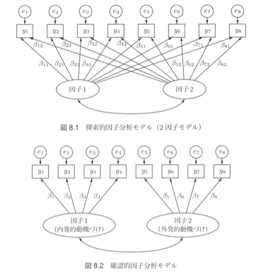

- 構造方程式：変数間の影響関係を表現するための式
  - 構成概念→構成概念：構成概念が他の構成概念の原因となる
  - 観測変数→観測変数：観測変数が他の観測変数の原因となる
    - 普通の回帰分析と一致
  - 観測変数→構成概念：観測変数が構成概念の原因となる

## 確証的因子分析の順番

- 仮説に基づくモデルの表現
- モデルの評価
- 結果の解釈

## 前回と同じデータを使います

- 最初にパッケージを読み込みます．

```r
# install.packages("lavaan")
library(lavaan)
```

```r
# install.packages("semPlot")
library(semPlot)
```

## モデルの表現

- `=~`，`~~`，`+` を使ってモデルを表現します．
  - ホントは細かいルールがあるのですが，次回改めて説明します．
  - `=~` ：左辺に因子名（構成概念），右辺にその因子から影響を受ける観測変数名を記述する
  - `~~` ：共分散が仮定できる場合に使うがが，ここではおいておく
    - 構成概念同士は共分散が算出される
  - `+` ：観測変数をつなぐ
- ここでは以下の通り分類されるものとする．
  - 合理性：項目1 + 項目4 + gyaku_項目5 +逆転項目8 + 逆転項目15 +逆転項目23 + 項目6 + 逆転項目10 +項目14 + 項目16 + 項目20 +逆転項目24
  - 直感性：項目3 + 項目7 + 逆転項目9 +逆転項目18 + 項目21 + 項目22 +逆転項目2 + 項目11 + 逆転項目12 +項目13 + 逆転項目17 + 項目19

```r
infostyle_model<-'
rat =~ ratemo_1 + ratemo_4 + gyaku_ratemo_5 +
gyaku_ratemo_8 + gyaku_ratemo_15 +
gyaku_ratemo_23 + ratemo_6 + gyaku_ratemo_10 +
ratemo_14 + ratemo_16 + ratemo_20 +
gyaku_ratemo_24

emo =~ ratemo_3 + ratemo_7 + gyaku_ratemo_9 +
gyaku_ratemo_18 + ratemo_21 + ratemo_22 +
gyaku_ratemo_2 + ratemo_11 + gyaku_ratemo_12 +
ratemo_13 + gyaku_ratemo_17 + ratemo_19
'
```

## 母数の推定

- lavaanの中のcfa()によって母数の推定を行う

```r
infostyle_model_fit <- cfa(infostyle_model,
                           data = factanal,
                           std.lv = TRUE)
```

- 先程作成したモデルとデータ名を記述する．
- 因子の分散を1に固定して分析することを指定している．
  - 教科書8.5.2を参照のこと

## 結果の出力

```r
summary(infostyle_model_fit,
        fit.measures = TRUE, # 適合指標を表示する
        standardized = TRUE)
```

```
## lavaan 0.6-7 ended normally after 16 iterations
##
##   Estimator                                         ML
##   Optimization method                           NLMINB
##   Number of free parameters                         49
##
##   Number of observations                           794
##
## Model Test User Model:
##
##   Test statistic                              2208.972
##   Degrees of freedom                               251
##   P-value (Chi-square)                           0.000
##
## Model Test Baseline Model:
##
##   Test statistic                              8655.575
##   Degrees of freedom                               276
##   P-value                                        0.000
##
## User Model versus Baseline Model:
##
##   Comparative Fit Index (CFI)                    0.766
##   Tucker-Lewis Index (TLI)                       0.743
##
## Loglikelihood and Information Criteria:
##
##   Loglikelihood user model (H0)             -24400.623
##   Loglikelihood unrestricted model (H1)     -23296.137
##
##   Akaike (AIC)                               48899.245
##   Bayesian (BIC)                             49128.422
##   Sample-size adjusted Bayesian (BIC)        48972.821
##
## Root Mean Square Error of Approximation:
##
##   RMSEA                                          0.099
##   90 Percent confidence interval - lower         0.095
##   90 Percent confidence interval - upper         0.103
##   P-value RMSEA <= 0.05                          0.000
```

[output cut: 58 more lines]

```
##    .gyaku_ratem_24    0.711    0.039   18.160    0.000    0.711    0.527
##    .ratemo_3          0.726    0.039   18.573    0.000    0.726    0.676
##    .ratemo_7          0.940    0.048   19.380    0.000    0.940    0.837
##    .gyaku_ratemo_9    0.929    0.050   18.572    0.000    0.929    0.675
##    .gyaku_ratem_18    0.532    0.030   17.955    0.000    0.532    0.589
##    .ratemo_21         0.626    0.033   19.231    0.000    0.626    0.802
##    .ratemo_22         0.423    0.025   16.931    0.000    0.423    0.486
##    .gyaku_ratemo_2    0.801    0.043   18.746    0.000    0.801    0.705
##    .ratemo_11         0.550    0.030   18.128    0.000    0.550    0.611
##    .gyaku_ratem_12    0.917    0.048   19.101    0.000    0.917    0.773
##    .ratemo_13         0.619    0.034   18.305    0.000    0.619    0.635
##    .gyaku_ratem_17    0.528    0.030   17.437    0.000    0.528    0.532
##    .ratemo_19         0.464    0.028   16.705    0.000    0.464    0.468
##     rat               1.000                               1.000    1.000
##     emo               1.000                               1.000    1.000
```

## モデル適合に関する指標

- \(\chi^2\) 値：帰無仮説が採択されるとよいが，データが多すぎると有意になりがち．

- これだけで評価してはいけない
- CFI(Comparative Fit Index，比較適合度指標)：0-1の間の数値を取る指標，1に近いほど当てはまりがよく，0.95以上あれば良いモデル．
- TLI(Tucker-Lewis Index)も1に近いほど当てはまりが良いが，1を超えることもある
- RMSEA：0.05以下であれば当てはまりがよく，0.1以上であれば当てはまりが悪い．
- SRMR(Standardized Root Mean Square Residual，標準化残差平方平均)：標本の分散，共分散とモデルにより再現される分散・共分散の差である残差によってモデル適合を検討する指標．0に近いほど当てはまっている．
- 今回は元のモデルの妥当性，ならびにSRMRを元にモデル評価を行い，元のモデル通りで良いものとする．

## モデルの出力

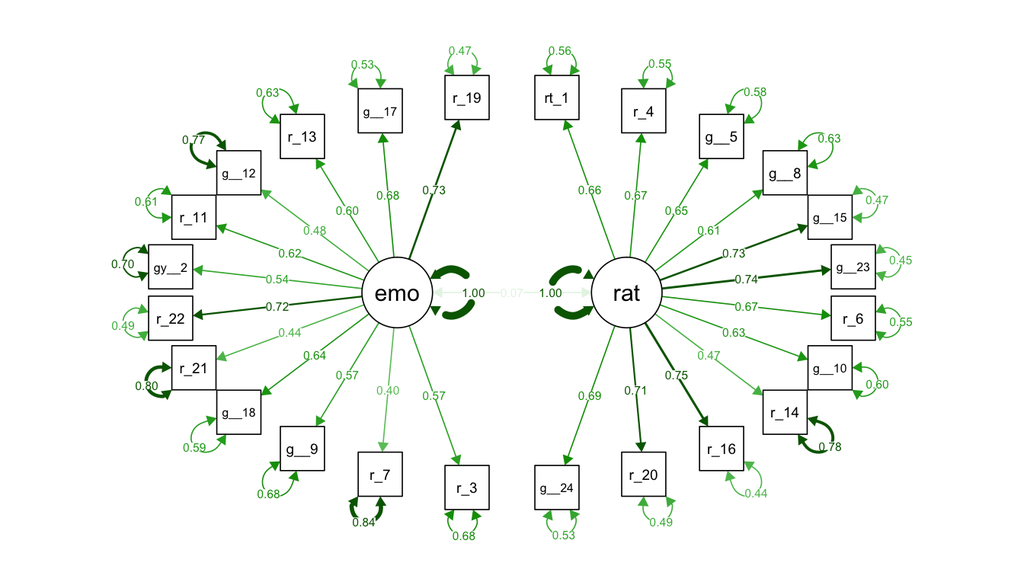

```r
semPaths(infostyle_model_fit, "std",
         title = FALSE, layout="circle2")
```

## 分析結果の解釈

- 2種類の母数推定
  - 非標準化推定値：データを標準化せずに分析を行った際に得られる推定値，変数単位の影響を受ける．
  - 標準化推定値：データを標準化して分析を行った際に得られる推定値，すべての構造変数が標準化されているので，単位の影響を受けない．
    - 「構成概念」を扱うときには非標準化推定値の解釈が難しいために，標準化推定値を報告することが多い

## 非標準化推定値の算出(信頼区間も)

```r
parameterestimates(infostyle_model_fit)
```

```
##                lhs op             rhs   est    se      z pvalue ci.lower
## 1              rat =~        ratemo_1 0.701 0.034 20.349  0.000    0.634
## 2              rat =~        ratemo_4 0.683 0.033 20.530  0.000    0.618
## 3              rat =~  gyaku_ratemo_5 0.675 0.034 19.745  0.000    0.608
## 4              rat =~  gyaku_ratemo_8 0.621 0.034 18.317  0.000    0.555
## 5              rat =~ gyaku_ratemo_15 0.801 0.035 22.964  0.000    0.733
## 6              rat =~ gyaku_ratemo_23 0.735 0.031 23.598  0.000    0.674
## 7              rat =~        ratemo_6 0.742 0.036 20.695  0.000    0.672
## 8              rat =~ gyaku_ratemo_10 0.652 0.034 19.077  0.000    0.585
## 9              rat =~       ratemo_14 0.451 0.033 13.501  0.000    0.386
## 10             rat =~       ratemo_16 0.803 0.034 23.898  0.000    0.737
## 11             rat =~       ratemo_20 0.795 0.035 22.410  0.000    0.725
## 12             rat =~ gyaku_ratemo_24 0.799 0.037 21.362  0.000    0.726
## 13             emo =~        ratemo_3 0.590 0.036 16.517  0.000    0.520
## 14             emo =~        ratemo_7 0.427 0.038 11.132  0.000    0.352
```

[output cut: 89 more lines]

## 標準化推定値の算出

```r
standardizedsolution(infostyle_model_fit)
```

```
##                lhs op             rhs est.std    se      z pvalue ci.lower
## 1              rat =~        ratemo_1   0.663 0.022 30.439  0.000    0.620
## 2              rat =~        ratemo_4   0.667 0.022 30.942  0.000    0.625
## 3              rat =~  gyaku_ratemo_5   0.648 0.022 28.818  0.000    0.604
## 4              rat =~  gyaku_ratemo_8   0.610 0.024 25.315  0.000    0.563
## 5              rat =~ gyaku_ratemo_15   0.726 0.019 38.630  0.000    0.689
## 6              rat =~ gyaku_ratemo_23   0.740 0.018 40.959  0.000    0.704
## 7              rat =~        ratemo_6   0.672 0.021 31.407  0.000    0.630
## 8              rat =~ gyaku_ratemo_10   0.630 0.023 27.127  0.000    0.585
## 9              rat =~       ratemo_14   0.472 0.029 16.060  0.000    0.414
## 10             rat =~       ratemo_16   0.747 0.018 42.118  0.000    0.712
## 11             rat =~       ratemo_20   0.713 0.019 36.715  0.000    0.675
## 12             rat =~ gyaku_ratemo_24   0.688 0.021 33.370  0.000    0.647
## 13             emo =~        ratemo_3   0.570 0.027 21.395  0.000    0.517
## 14             emo =~        ratemo_7   0.403 0.032 12.515  0.000    0.340
```

[output cut: 89 more lines]

## その他の指標

- 構成概念スコア：研究仮説で過程した構成概念の尺度上で，各観測対象がどの程度その特性を持っているのか示した値
  - 標準化された値が表示されている．

```r
infostyle_model_fit_predict<-
  predict(infostyle_model_fit)
infostyle_model_fit_predict
```

```
##           rat    emo
##   [1,] -0.589  0.236
##   [2,]  0.544 -1.235
##   [3,] -0.347  0.969
##   [4,] -1.074  2.487
##   [5,]  0.525  1.635
##   [6,]  0.353  0.691
##   [7,]  0.030  0.430
##   [8,]  0.753  0.537
##   [9,] -1.135  0.008
##  [10,]  1.288 -0.185
##  [11,]  0.151  0.065
##  [12,]  0.882  1.472
##  [13,] -1.001  0.113
##  [14,]  0.983 -1.861
```

[output cut: 780 more lines]

## 構成概念スコアとデータを接合する

```r
new_factanal<-
  cbind(factanal, infostyle_model_fit_predict)
```

## 構成概念スコアの変わりに合計値を使うことがある

- 合計値なので，そこまで大きく変わらないはず．

```r
new_factanal2 <- new_factanal %>%
  mutate(rat_sum = ratemo_1 + ratemo_4 + gyaku_ratemo_5 +
           gyaku_ratemo_8 + gyaku_ratemo_15 +
           gyaku_ratemo_23 + ratemo_6 + gyaku_ratemo_10 +
           ratemo_14 + ratemo_16 + ratemo_20 +
           gyaku_ratemo_24,
         emo_sum = ratemo_3 + ratemo_7 + gyaku_ratemo_9 +
           gyaku_ratemo_18 + ratemo_21 + ratemo_22 +
           gyaku_ratemo_2 + ratemo_11 + gyaku_ratemo_12 +
           ratemo_13 + gyaku_ratemo_17 + ratemo_19)
```

## 演習問題

## 演習問題：

- 以下の問題を回答してください．
1. 以下データセットfactanalには，一般的に人を信じやすい指標として用いられる「一般的信頼尺度」が入っています．項目は以下のとおりです．
- Trust1_gen：ほとんどの人は基本的に正直である
- Trust2_gen：私は人を信頼するほうである
- Trust3_gen：ほとんどの人は基本的に善良で親切である
- Trust4_gen：ほとんどの人は他人を信頼している
- Trust5_gen：ほとんどの人は信用できる
- 逆転項目なし

1.1 これについて，探索的因子分析を行ってください．

1.2 これについて，確認的因子分析を行ってください．なお，一因子モデルとします．

1.3 因子構造を確認した後，Trust1_genからTrust5_genまでを合計して構成概念スコアおよび合計得点を算出してください．

1.4 合計点に男女差が存在するかどうか検証してください．

- 因子得点を算出してから，t検定を行います．

## 演習問題：

1. 余裕があれば，教科書p.185-192までを読んでおいてください．
- 適宜，手を動かして計算をしてみましょう．